# Comparing Age and Growth Increments from Bayesian and integrative data approaches for the deepwater snapper Pristipomoides filamentosus in the Hawaiian Islands

Written By Stephen Scherrer Latest Major Revision 20 July 2020

This Notebook contains code to run analysis and produce plots associated with the manuscript “Comparing Age and Growth Increments from Bayesian and integrative data approaches for the deepwater snapper Pristipomoides filamentosus in the Hawaiian Islands” It is devided into the following sections:

1. Workspace Setup
2. Bayesian Analysis (Models I - IV)
3. Maximum Likelihood Integrative Approach (Models 5-11)
4. Sensitivity Analysis
5. Plotting Figures
6. Workspace Cleanup
7. Additional Notes

# 1. Workspace Setup

### Clearing R enviornment

```r
## Clearing R enviornment
rm(list = ls())
gc()
```

```
          used (Mb) gc trigger  (Mb) limit (Mb) max used  (Mb)
Ncells  862087 46.1    1813460  96.9         NA  1813460  96.9
Vcells 2005273 15.3   62724302 478.6      16384 54102122 412.8
```

```r
set.seed(42)
```

### Establishing Directory Heirarchy

```r
## Establishing Directory Heirarchy
proj_dir = getwd()
proj_dir = "/Volumes/GoogleDrive/My Drive/Weng Lab/Personal_Folders/Steve/dissertation work/Ch 4. Opakapaka Growth/Analysis"
data_dir = file.path(proj_dir, 'data')
src_dir = file.path(proj_dir, 'src')
results_dir = file.path(proj_dir, 'results')
```

### Importing Packages and Dependencies

### Loading saved workspace

After this script concludes, an workspace image will be saved so results can be accessed without re-running growth models. If this workspace already exists, we’ll load it in now.

```r
if(file.exists(file.path(results_dir, 'Paka VBGF Workspace For FR Revisions.RData'))){
  load(file.path(results_dir, 'Paka VBGF Workspace For FR Revisions.RData'))
}
```

### Defining Global Hyperparameters

```r
min_time_at_lib = 60 # days
```

## 2. Bayesian Analysis (Models I - IV)

The following section uses JAGS to fit bayesian models under different constraints using the OTP data only.

### Importing and preprocessing OTP Data

```r
otp_data = load_okomoto_data()
```

### Formatting Data for Bayesian Modeling

The next sections create an list object named “data” consisting of the following objects:

L: A matrix of fork lengths (cm). Rows are individuals, columns are capture events dt: A matrix of delta t (years) corrosponding to time between capture events. n: A vector where values represent the number of valid recaptures for individuals N: A numeric variable corrosponding to the number of unique fish in our dataset

```r
### L: A matrix of fork lengths (cm). Rows are individuals, columns are capture events
L = cbind(
  otp_data$fork_length,
  otp_data$recapture_1_fork_length,
  otp_data$recapture_2_fork_length,
  otp_data$recapture_3_fork_length,
  otp_data$recapture_4_fork_length
  )

### dt: A matrix of delta t (years) corrosponding to time between capture events. Column 1 is a dummy column that will be removed before data is wrapped in a list
dt = cbind(
  rep(9999, length(otp_data$recapture_1_date)),
  difftime(otp_data$recapture_1_date, otp_data$tag_date, unit = 'days') / 365,
  difftime(otp_data$recapture_2_date, otp_data$tag_date, unit = 'days') / 365,
  difftime(otp_data$recapture_3_date, otp_data$tag_date, unit = 'days') / 365,
  difftime(otp_data$recapture_4_date, otp_data$tag_date, unit = 'days') / 365
  )

### Ommitting data when the time at liberty is less than our defined minimum period
L[dt < min_time_at_lib / 365] = NA
dt[dt < min_time_at_lib / 365] = NA

### Removing any data from fish without a valid recapture event.
rm_ind = c()
## Loop through each individual
for(i in 1:nrow(L)){
  ## Flag individuals with less than 2 valid recaptures (number of NA values present is greater than 1)
  if(length(which(!is.na(L[i, ]))) < 2){
    rm_ind = c(rm_ind, i)
  } else if(length(which(!is.na(dt[i, ]))) < 2){
    rm_ind = c(rm_ind, i)
  }
}
## Remove data flagged for removal
L = L[-rm_ind, ]; dt = dt[-rm_ind, ]

### Left justifying matricies dt and L
## Loop through each individual
for(i in 1:nrow(L)){
  ## If they have any NA values (total captures < 5)
  if(any(is.na(L[i, ]))){
    ## For as long as there is an NA value with a numeric right ajacent
    while(min(which(is.na(dt[i, ]))) < max(which(!is.na(dt[i, ])))){
      # remove NA value and shift subsequent values over. Append NA to end to maintain matrix dimensions
      dt[i, ] = c(
        dt[i, 1:min(which(is.na(L[i, ])))-1],
        dt[i, (min(which(is.na(L[i, ])))+1):length(L[i, ])],
        NA)

      L[i, ] = c(
        L[i, 1:min(which(is.na(L[i, ])))-1],
        L[i, (min(which(is.na(L[i, ])))+1):length(L[i, ])],
        NA)
    }
  }
}

## dt still has a column on the right that is full of temporary values. Here they're removed
dt = dt[ ,-1]

## Ommitting data when the time at liberty is less than our defined minimum period
L[dt < min_time_at_lib / 365] = NA
dt[dt < min_time_at_lib / 365] = NA

#### Getting values of n, a vector where values represent the number of valid recaptures for individuals
n = rep(0, nrow(dt))
for(i in 1:length(n)){
  n[i] = length(L[i, ]) - length(which(is.na(L[i, ])))
}

#### Wrapping all our data into a list for our model
data = list(n = n, L = L, dt = dt, N = length(n))

## Print number of rows in L. Should be 387
dim(L)[1] == 387
```

### Defining Bayesian Models 1-4 With Priors for Linf_mu and K_mu

In this chunk, we define 4 models that differ in the way they that they treat VBGF parameters Linf and K.

Model 1: L infinity (Linf) and k will be allowed to vary between individuals. No Fixed Effects Model 2: Linf is allowed to vary between individuals. K is fixed Model 3: k is allowed to vary. Linf is fixed Model 4: Linf and k are fixed.

Note that some parameters in models 2 and 4 have been truncated to avoid upsetting the MCMC slicing algorthm

Prior Values from Andrewws: L⬁ ⫽ 67.5 com FL (1.8 cm), K ⫽ 0.242 (⫾0.057), and t0 ⫽ –0.29 years (⫾0.09 years). Correlations among the VBGF parameters were ?(L⬁,K) ⫽ –0.21, ?(L⬁,t0) ⫽ –0.14, and ?(t0,K) ⫽ 0.30.

```r
## Defining model 1
cat('
# Model 1
model{
    for (i in 1:N)   {
    # for (j in 2:n[i]) {
        for (j in n[i]) {
            L[i, j] ~ dnorm(L_Exp[i, j], tau)
            L_Exp[i, j] <-  Linf[i] *(1.0 - exp(-k[i]*(A[i]+dt[i, j -1])))
            # posterior prediction
            L.pred[i, j] ~ dnorm(L_Exp[i, j], tau)
            p.value[i, j] <- step(L.pred[i, j] - L[i, j])
        }
        L[i, 1] ~ dnorm(L_Exp[i, 1], tau)
        L_Exp[i, 1] <-   Linf[i] *(1.0 - exp(-k[i]*A[i]))

        # posterior prediction
        L.pred[i, 1] ~ dnorm(L_Exp[i, 1], tau)
        p.value[i, 1] <- step(L.pred[i, 1]- L[i, 1])

        Linf[i] ~ dnorm(Linf_mu,  Linf_tau)
        k[i] ~ dnorm(k_mu, k_tau) T(0,1)
        A[i] ~ dgamma(Shape, rate)
    }

        Linf_std <- sqrt(1/Linf_tau)
        k_std <- sqrt(1/k_tau)
        variance <- 1/tau
        Linf_mu ~ dnorm(71.39, 0.0001)
        Linf_tau ~ dgamma(0.01, 0.0001)
        Shape ~ dunif(0, 100)
        rate ~ dunif(0, 100)
        k_mu ~ dnorm(0.268, k_perc) T(0.01,0.99)
        k_tau ~ dgamma(01, 0.0001)
        tau ~ dgamma(0.001, 0.0001)

        # SD of parameters
        sig.linf <- 12.34 * 2
        sig.k <- 0.0932 * 2

      # Percision
        linf_perc = pow(sig.linf, -2)
        k_perc = pow(sig.k, -2)
}',
file = file.path(src_dir, "JAGS Models/VBGF JAGS Model 1.txt")
)

## Defining model 2
cat(
  '# Model 2
model{
    for (i in 1:N)   {
        # for (j in 2:n[i]) {
        for (j in n[i]) {
            L[i, j] ~ dnorm(L_Exp[i, j], tau)
            L_Exp[i, j] <-  Linf[i] *(1.0 - exp(-k*(A[i]+dt[i, j -1])))
            L.pred[i, j] ~ dnorm(L_Exp[i, j], tau)
            p.value[i, j] <- step(L.pred[i, j] - L[i, j])
        }
        L[i, 1] ~ dnorm(L_Exp[i, 1], tau)
        L_Exp[i, 1] <-   Linf[i] *(1.0 - exp(-k*A[i]))
        L.pred[i, 1] ~ dnorm(L_Exp[i, 1], tau)
        p.value[i, 1] <- step(L.pred[i, 1]- L[i, 1])
        Linf[i] ~ dnorm(Linf_mu,  Linf_tau)
        A[i] ~ dgamma(Shape, rate)
    }
  Linf_std <- sqrt(1/Linf_tau)
    k_std <- sqrt(1/k_tau)
    variance <- 1/tau
    k ~ dnorm(k_mu, k_tau)
  Linf_mu ~ dnorm(71.39, linf_perc)
    Linf_tau ~ dgamma(0.01, 0.0001)
    Shape ~ dunif(0, 100)
    rate ~ dunif(0, 100)
    k_mu ~ dnorm(0.268, k_perc) T(0.01,0.99)
    k_tau ~ dgamma(01, 0.0001)
    tau ~ dgamma(0.001, 0.0001)

    # SD of Parameters
        sig.linf <- 12.34 * 2
        sig.k <- 0.0932 * 2

    # Percision
    linf_perc = pow(sig.linf, -2)
    k_perc = pow(sig.k, -2)
}
    ',
file = file.path(src_dir, "JAGS Models/VBGF JAGS Model 2.txt")
)

## Defining model 3
cat('
  # Model 3
model{
    for (i in 1:N)   {
    # for (j in 2:n[i]) {
        for (j in n[i]) {
            L[i, j] ~ dnorm(L_Exp[i, j], tau)
            L_Exp[i, j] <-  Linf*(1.0 - exp(-k[i]*(A[i]+dt[i, j -1])))
            L.pred[i, j] ~ dnorm(L_Exp[i, j], tau)
            p.value[i, j] <- step(L.pred[i, j] - L[i, j])
        }
        L[i, 1] ~ dnorm(L_Exp[i, 1], tau)
        L_Exp[i, 1] <-   Linf *(1.0 - exp(-k[i]*A[i]))
        L.pred[i, 1] ~ dnorm(L_Exp[i, 1], tau)
        p.value[i, 1] <- step(L.pred[i, 1]- L[i, 1])
    k[i] ~ dnorm(k_mu, k_tau) T(0,1)
        A[i] ~ dgamma(Shape, rate)
    }
    Linf_std <- sqrt(1/Linf_tau)
    k_std <- sqrt(1/k_tau)
    variance <- 1/tau
    Linf ~ dnorm(Linf_mu,  Linf_tau)
  Linf_mu ~ dnorm(71.39, linf_perc)
    Linf_tau ~ dgamma(0.01, 0.0001)
    Shape ~ dunif(0, 100)
    rate ~ dunif(0, 1000)
    k_mu ~ dnorm(0.268, k_perc) T(0.01,0.99)
    k_tau ~ dgamma(.01, 0.0001)
    tau ~ dgamma(0.01, 0.0001)

      # SD of Parameters
        sig.linf <- 12.34 * 2
        sig.k <- 0.0932 * 2

    # Percision
    linf_perc = pow(sig.linf, -2)
    k_perc = pow(sig.k, -2)
}',
file = file.path(src_dir, "JAGS Models/VBGF JAGS Model 3.txt")
)

## Defining model 4
cat(
  '# Model 4
model{
    for (i in 1:N)   {
        # for (j in 2:n[i]) {
        for (j in n[i]) {
            L[i, j] ~ dnorm(L_Exp[i, j], tau)
            L_Exp[i, j] <-  Linf*(1.0 - exp(-k*(A[i]+dt[i, j-1])))
            L.pred[i, j] ~ dnorm(L_Exp[i, j], tau)
            p.value[i, j] <- step(L.pred[i, j] - L[i, j])
        }
    # Predicting length at capture
        L[i, 1] ~ dnorm(L_Exp[i, 1], tau)
        L_Exp[i, 1] <-   Linf *(1.0 - exp(-k*A[i]))
        L.pred[i, 1] ~ dnorm(L_Exp[i, 1], tau)
        p.value[i, 1] <- step(L.pred[i, 1]- L[i, 1])
        A[i] ~ dgamma(Shape, rate)
    }
    k_std <- sqrt(1/k_tau)
    variance <- 1/tau
    k ~ dnorm(k_mu, k_tau)
    Linf ~ dnorm(Linf_mu,  Linf_tau)
  Linf_mu ~ dnorm(71.39, linf_perc)
    Linf_tau ~ dgamma(0.01, 0.0001)
    Linf_std <- sqrt(1/Linf_tau)
    Shape ~ dunif(0, 100)
    rate ~ dunif(0, 100)
    k_mu ~ dnorm(0.268, k_perc) T(0.01,0.99)
    k_tau ~ dgamma(01, 0.0001)
    tau ~ dgamma(0.001, 0.0001)

      # SD of Parameters
        sig.linf <- 12.34 * 2
        sig.k <- 0.0932 * 2

    # Percision
    linf_perc = pow(sig.linf, -2)
    k_perc = pow(sig.k, -2)
}
',
file = file.path(src_dir, "JAGS Models/VBGF JAGS Model 4.txt")
)
```

### Defining Bayesian Model Hyperparameters

Here we’ll define inits, a list of initial starting points for our optimizer. inits is a list containing a set of lists corrosponding to each chain we’ll run in our optimizer. For this analyis there will be 3 chains. The first we’ll set using some reasonable estimates from our maximum likelihood work, the remaining 2 will use values 2X larger and smaller than the first chain.

```r
## Initial values for each chain are stored in 3 lists with elements corrosponding to all variables to be initialized
inits1 = list('Linf_mu' = 67.5,   'k_mu' = 0.242)
inits2 = list('Linf_mu' = 67.5*2, 'k_mu' = 0.242*2)
inits3 = list('Linf_mu' = 67.5/2, 'k_mu' = 0.242/2)
## Creating a single list that contains the lists corrosponding to each chain's initial values
inits = list(inits1, inits2, inits3)

## Chain parameters
# The number of samples in the posterior distribution = (n_iterations - n_burnin) / n_thin
n_iterations = 2000000 # How many total iterations to run
n_burnin = 150000 # How many iterations to run during the model's burn in phase
n_thin = 50 # Retain one in n_thin samples from the posterior distribution.
```

### Running Bayesian Models - With Priors for Linf_mu and k_mu

```r
# n_iterations = 100000 # How many total iterations to run
# n_burnin = 150 # How many iterations to run during the model's burn in phase
# n_thin = 50 # R

## Model 1: Linf and K vary between individuals
model_1 = jags(data, inits,
               model.file = file.path(src_dir, "JAGS Models/VBGF JAGS Model 1.txt"),
               parameters.to.save =  c('Linf_mu', 'Linf_std', 'Linf_tau', 'Shape', 'k_mu', 'k_std', 'k_tau', 'rate', 'tau', 'variance'),
               DIC = T,
               n.chains = 3, n.iter = n_iterations, n.burnin = n_burnin, n.thin = n_thin)
```

```
module glm loaded
```

[output not shown]

```r
print(model_1$BUGSoutput$summary)
```

```
                 mean           sd         2.5%          25%          50%
Linf_mu  6.125861e+01 1.812354e+00 5.797184e+01 5.999668e+01 6.114687e+01
Linf_std 5.297332e+00 3.502675e-01 4.618238e+00 5.060578e+00 5.294793e+00
Linf_tau 3.611152e-02 4.866316e-03 2.785072e-02 3.268965e-02 3.566991e-02
Shape    3.103945e+01 5.256046e+00 2.240154e+01 2.732426e+01 3.046231e+01
deviance 3.400315e+03 1.052216e+02 3.181784e+03 3.332328e+03 3.404700e+03
k_mu     2.966103e-01 2.809431e-02 2.432480e-01 2.774879e-01 2.961381e-01
k_std    9.102501e-03 3.175342e-03 4.678289e-03 6.794034e-03 8.497911e-03
k_tau    1.664467e+04 1.118004e+04 3.503237e+03 8.612741e+03 1.384764e+04
rate     1.171978e+01 1.809352e+00 8.713653e+00 1.044392e+01 1.153315e+01
tau      2.133771e-01 3.154474e-02 1.612516e-01 1.910454e-01 2.100746e-01
variance 4.785838e+00 6.864115e-01 3.515613e+00 4.309447e+00 4.760214e+00
                  75%        97.5%     Rhat  n.eff
Linf_mu  6.239996e+01 6.513812e+01 1.006270    380
Linf_std 5.530888e+00 5.992137e+00 1.001157  12000
Linf_tau 3.904808e-02 4.688645e-02 1.001157  12000
Shape    3.411494e+01 4.303553e+01 1.002871   1100
deviance 3.473011e+03 3.594307e+03 1.003217    900
k_mu     3.151438e-01 3.542319e-01 1.006382    370
k_std    1.077530e-02 1.689527e-02 1.001002 110000
k_tau    2.166430e+04 4.569051e+04 1.001002 110000
rate     1.278615e+01 1.581695e+01 1.001508   3800
tau      2.320484e-01 2.844454e-01 1.003194    910
variance 5.234359e+00 6.201490e+00 1.003194    910
```

```r
beep()
save.image(file.path(results_dir, 'Paka VBGF Workspace For FR Revisions.RData'))

## Model 2: Linf varies between individuals, K is fixed
model_2 = jags(data, inits,
               model.file = file.path(src_dir, "JAGS Models/VBGF JAGS Model 2 - updated priors.txt"),
               parameters.to.save =  c('Linf_mu', 'Linf_std', 'Linf_tau', 'Shape', 'k_mu', 'k_std', 'k_tau', 'rate', 'tau', 'variance'),
               DIC = T,
               n.chains = 3, n.iter = n_iterations, n.burnin = n_burnin, n.thin = n_thin)
```

[output not shown]

```r
print(model_2$BUGSoutput$summary)
```

```
                 mean           sd         2.5%          25%          50%
Linf_mu  6.179143e+01 1.796696e+00 5.852067e+01 6.054130e+01 6.169225e+01
Linf_std 5.326671e+00 3.487627e-01 4.649726e+00 5.091412e+00 5.323254e+00
Linf_tau 3.570499e-02 4.758022e-03 2.757818e-02 3.237150e-02 3.528951e-02
Shape    3.111459e+01 5.086213e+00 2.268390e+01 2.752407e+01 3.059139e+01
deviance 3.413194e+03 1.011195e+02 3.201740e+03 3.348026e+03 3.417042e+03
k_mu     2.873025e-01 3.164159e-02 2.267499e-01 2.668705e-01 2.869939e-01
k_std    1.630794e-02 1.692206e-02 5.177747e-03 8.443560e-03 1.185982e-02
k_tau    1.017340e+04 1.009844e+04 3.410726e+02 3.008339e+03 7.109575e+03
rate     1.156776e+01 1.749205e+00 8.656102e+00 1.033415e+01 1.139022e+01
tau      2.097372e-01 3.000615e-02 1.598364e-01 1.884929e-01 2.067138e-01
variance 4.862702e+00 6.763200e-01 3.606634e+00 4.394400e+00 4.837606e+00
                  75%        97.5%     Rhat  n.eff
Linf_mu  6.293663e+01 6.561674e+01 1.002501   1300
Linf_std 5.558000e+00 6.021674e+00 1.001016  64000
Linf_tau 3.857656e-02 4.625357e-02 1.001016  64000
Shape    3.411172e+01 4.269288e+01 1.001622   3100
deviance 3.483489e+03 3.599659e+03 1.001454   4300
k_mu     3.074564e-01 3.504581e-01 1.002010   2000
k_std    1.823210e-02 5.414727e-02 1.000990 110000
k_tau    1.402648e+04 3.730082e+04 1.000990 110000
rate     1.259001e+01 1.552621e+01 1.001354   5400
tau      2.275623e-01 2.772669e-01 1.001398   4900
variance 5.305241e+00 6.256398e+00 1.001398   4900
```

```r
save.image(file.path(results_dir, 'Paka VBGF Workspace For FR Revisions.RData'))

## Model 3: K varies between individuals, Linf is fixed
model_3 = jags(data, inits,
               model.file = file.path(src_dir, "JAGS Models/VBGF JAGS Model 3 - updated priors.txt"),
               parameters.to.save =  c('Linf_mu', 'Linf_std', 'Linf_tau', 'Shape', 'k_mu', 'k_std', 'k_tau', 'rate', 'tau', 'variance'),
               DIC = T,
               n.chains = 3, n.iter = n_iterations, n.burnin = n_burnin, n.thin = n_thin)
```

[output not shown]

```r
print(model_3$BUGSoutput$summary[,1])
```

```
     Linf_mu     Linf_std     Linf_tau        Shape     deviance         k_mu
7.368639e+01 2.202449e+01 7.177924e+02 6.354450e+01 3.848006e+03 1.732348e-01
       k_std        k_tau         rate          tau     variance
2.068462e-02 2.500277e+03 1.840174e+01 1.187589e-01 8.473848e+00
```

```r
save.image(file.path(results_dir, 'Paka VBGF Workspace For FR Revisions.RData'))

## Model 4: Linf and K are fixed
model_4 = jags(data, inits,
               model.file = file.path(src_dir, "JAGS Models/VBGF JAGS Model 4 - updated priors.txt"),
               parameters.to.save =  c('Linf_mu', 'Linf_std', 'Linf_tau', 'Shape', 'k_mu', 'k_std', 'k_tau', 'rate', 'tau', 'variance'),
               DIC = T,
               n.chains = 3, n.iter = n_iterations, n.burnin = n_burnin, n.thin = n_thin)
```

[output not shown]

```r
print(model_4$BUGSoutput$summary[,1])
```

```
     Linf_mu     Linf_std     Linf_tau        Shape     deviance         k_mu
7.367495e+01 1.556643e+01 7.147105e+02 3.294389e+01 3.988922e+03 1.753468e-01
       k_std        k_tau         rate          tau     variance
1.688043e-02 1.004104e+04 9.402147e+00 9.896525e-02 1.015835e+01
```

```r
growth_models = list('model_1' = model_1, 'model_2' = model_2, 'model_3' = model_3, 'model_4' = model_4)

save.image(file.path(results_dir, 'Paka VBGF Workspace For FR Revisions.RData'))
```

## Bayesian Model Diagnostics

Producing diagnostic plots and checking convergence for each of our 4 growth models,

```r
##### Model Diagnostics
for(i in 1:length(growth_models)){
  # readline(paste('Press Enter to View Diagnostics for', names(growth_models)[i]))
  model = growth_models[[i]]
  print(paste("Diagnostic plots for", names(growth_models)[i]))

  ## Write out model summary table
  write.csv(model$BUGSoutput[10], file.path(results_dir, paste( names(growth_models)[i], ' Parameter Summaries.csv')))
}

for(i in 1:length(growth_models)){
  ### Summary Statistics and Parameter Estimates
  summary(model)

  ### Generating MCMC object for analysis
  model_mcmc = as.mcmc(model)

  par(mfrow = c(2, 4))
  ### xy plot
  xyplot(model_mcmc)

  ### Trace and Density Plots
  plot(model_mcmc)

  ### Autocorrelation plots
  autocorr.plot(model_mcmc)

  #### Other Diagnostics using CODA package
  gelman.plot(model_mcmc)
  geweke.diag(model_mcmc)
  geweke.plot(model_mcmc)
  raftery.diag(model_mcmc)
  heidel.diag(model_mcmc)
}
dev.off()
```

We assume the model 1, which allows both L and K to be fit independently for each fish is the best model. A low coefficient of variation for parameters under this model should confirm this. We’ll then look at the remaining 3 models to see how variability in model terms is affected by fixing a given parameter across the population.

### Calculating Coefficient of Variation in Linf_mu and k_mu parameters for Bayesian Models

```r
#### Extracting coefficients of variation for Linf and K paramters
cv_df = data.frame(stringsAsFactors = F)
for(i in 1:length(growth_models)){
  curr_mod = growth_models[[i]]
  cv_df = rbind(cv_df, data.frame('model' = names(growth_models)[i], 'Parameter' = 'Linf', 'cv' = curr_mod$BUGSoutput$summary["Linf_mu",'sd'] / curr_mod$BUGSoutput$summary["Linf_mu","mean"] * 100),
                data.frame('model' = names(growth_models)[i], 'Parameter' = 'k', 'cv' = curr_mod$BUGSoutput$summary["k_mu",'sd'] / curr_mod$BUGSoutput$summary["k_mu","mean"] * 100))
}

## Adding the source of variability for each model and term to our data frame
cv_df$`source of individual variability` = 'Other'
cv_df$`source of individual variability`[cv_df$model == 'model_1'] = 'Both'
cv_df$`source of individual variability`[cv_df$model == 'model_4'] = 'Neither'
cv_df$`source of individual variability`[cv_df$model == 'model_2' & cv_df$Parameter == 'Linf'] = 'Self'
cv_df$`source of individual variability`[cv_df$model == 'model_3' & cv_df$Parameter == 'k'] = 'Self'
cv_df$`source of individual variability` = as.factor(cv_df$`source of individual variability`)
cv_df$`source of individual variability` = fct_relevel(cv_df$`source of individual variability`, c('Both', 'Self', 'Other', 'Neither'))
```

### Figure 3. Visualizing Coefficient of Variation for Bayesian Models

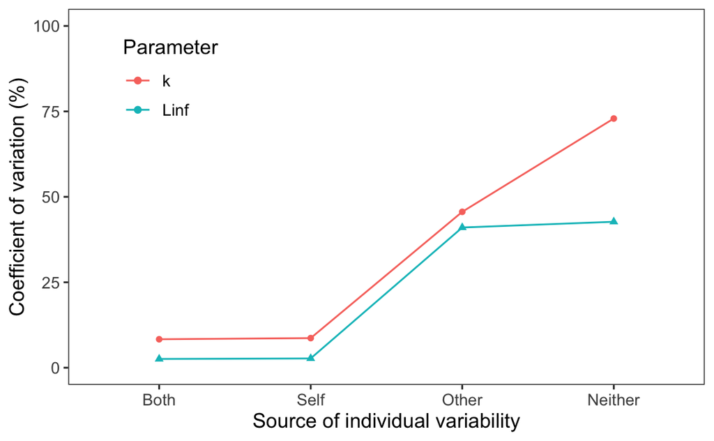

The x-axis labels indicate wether a term is fixed or not. “Both” refers to model 1 as both terms are fit independently. “Self”" and “Other” are models 2 and 3, while “neither” is model 4. We see that when both parameters are fit independently (model 1), both terms have the lowest coefficient of variation, indicating it is the model with the best fit. We see, unsuprisingly, as we make our effects fixed across the population, the deviation associated increases.

While model 1 is clearly the best performing model, when we compare parameter estimates from Models 1 and 2, we can infer the model 2, is likely credible as well.

The additional Models 2-4 suggested that individual variability in both K and L_∞ was important, with perhaps variability in L_∞ being more important based upon the response of L_∞ standard deviation from the base case of Model 1 to the constrained individual variability in Model 3 and Model 4.